# Machine Learning Competition: Predicting Car Insurance Claims

Erik Kollmer

8/8/2021

# 1 Introduction

This is my machine learning model building process for Zindi’s [Autoinland Vehicle Insurance Challenge](https://zindi.africa/competitions/autoinland-vehicle-insurance-claim-challenge). The goal of the competition was to assist the African car company Autoinland in predicting whether or not a customer would file a vehicle insurance claim in the next three months. I identified this as a binary classification task, where a machine learning model could be built to identify if a customer would file a vehicle insurance claim. Thus, the `target` variable data only has two levels: `1` indicates an insurance claim was filed, `0` meaning not filed.

Without further ado, let’s dive right in.

# 2 Exploratory Data Analysis (EDA)

## 2.1 Overview

Let’s take a glimpse at the overall data as well as the distribution of the target variable.

```r
library(tidyverse)
library(magrittr)
library(gridExtra)
library(graphics)
library(cowplot)
library(caret)
library(pROC)

raw_train <- read.csv("trainv2.csv")
raw_test <- read.csv("testv2.csv")

str(raw_train)
```

```
## 'data.frame':    12079 obs. of  14 variables:
##  $ ID                    : chr  "ID_0040R73" "ID_0046BNK" "ID_005QMC3" "ID_0079OHW" ...
##  $ Policy.Start.Date     : chr  "2010-05-14" "2010-11-29" "2010-03-21" "2010-08-21" ...
##  $ Policy.End.Date       : chr  "2011-05-13" "2011-11-28" "2011-03-20" "2011-08-20" ...
##  $ Gender                : chr  "Male" "Female" "Male" "Male" ...
##  $ Age                   : int  30 79 43 2 20 37 40 43 71 58 ...
##  $ First.Transaction.Date: chr  "2010-05-14" "2010-11-29" "2010-03-21" "2010-08-21" ...
##  $ No_Pol                : int  1 1 1 1 3 2 3 1 2 1 ...
##  $ Car_Category          : chr  "Saloon" "JEEP" "Saloon" "" ...
##  $ Subject_Car_Colour    : chr  "Black" "Grey" "Red" "" ...
##  $ Subject_Car_Make      : chr  "TOYOTA" "TOYOTA" "TOYOTA" "" ...
##  $ LGA_Name              : chr  "" "" "" "" ...
##  $ State                 : chr  "" "" "" "" ...
##  $ ProductName           : chr  "Car Classic" "Car Classic" "Car Classic" "CarSafe" ...
##  $ target                : int  0 1 0 0 1 0 0 0 0 0 ...
```

```r
str(raw_test)
```

```
## 'data.frame':    1202 obs. of  13 variables:
##  $ ID                    : chr  "ID_01QM0NU" "ID_024NJLZ" "ID_02NOVWQ" "ID_02VSP68" ...
##  $ Policy.Start.Date     : chr  "2010-10-23" "2010-10-14" "2010-08-29" "2010-06-13" ...
##  $ Policy.End.Date       : chr  "2011-10-22" "2011-10-13" "2011-08-28" "2011-06-12" ...
##  $ Gender                : chr  "Female" "Male" "Female" "Female" ...
##  $ Age                   : int  46 32 45 58 120 64 120 35 22 38 ...
##  $ First.Transaction.Date: chr  "2010-10-23" "2010-10-14" "2010-08-29" "2010-06-13" ...
##  $ No_Pol                : int  1 1 2 1 1 2 1 1 1 3 ...
##  $ Car_Category          : chr  "" "" "Saloon" "Saloon" ...
##  $ Subject_Car_Colour    : chr  "" "" "Black" "" ...
##  $ Subject_Car_Make      : chr  "Ford" "" "Honda" "TOYOTA" ...
##  $ LGA_Name              : chr  "Abuja Municipal" "Kosofe" "Wuse 11" "" ...
##  $ State                 : chr  "Abuja-Municipal" "Benue" "Abuja" "" ...
##  $ ProductName           : chr  "Car Classic" "Car Classic" "Car Classic" "CarSafe" ...
```

```r
prop.table(table(raw_train$target))
```

```
##
##        0        1
## 0.879543 0.120457
```

First, it seems that we have a fairly unbalanced train dataset in terms of the target variable (88/12 split). We may need to oversample to improve the model down the line.

Second, it appears that `Policy.Start.Date` could have the same values as `First.Transaction.Date`. Let’s confirm that.

```r
sum(raw_train$Policy.Start.Date == raw_train$First.Transaction.Date, na.rm = TRUE) == length(raw_train$Policy.Start.Date)
```

```
## [1] TRUE
```

We can also see what percentage of values are missing for each variable.

```r
colSums(raw_train == "")/nrow(raw_train)
```

```
##                     ID      Policy.Start.Date        Policy.End.Date
##              0.0000000              0.0000000              0.0000000
##                 Gender                    Age First.Transaction.Date
##              0.0297210              0.0000000              0.0000000
##                 No_Pol           Car_Category     Subject_Car_Colour
##              0.0000000              0.3094627              0.5763722
##       Subject_Car_Make               LGA_Name                  State
##              0.2049839              0.5361371              0.5371306
##            ProductName                 target
##              0.0000000              0.0000000
```

```r
colSums(raw_test == "")/nrow(raw_test)
```

```
##                     ID      Policy.Start.Date        Policy.End.Date
##             0.00000000             0.00000000             0.00000000
##                 Gender                    Age First.Transaction.Date
##             0.03410982             0.00000000             0.00000000
##                 No_Pol           Car_Category     Subject_Car_Colour
##             0.00000000             0.30948419             0.57986689
##       Subject_Car_Make               LGA_Name                  State
##             0.20632280             0.54575707             0.54575707
##            ProductName
##             0.00000000
```

It looks like `Subject_Car_Colour`, `LGA_Name`, and `State` all have more than half their values missing. This may make them difficult to use as predictors, but we can see how they fare with imputed values or as their own category.

## 2.2 Policy Start Date

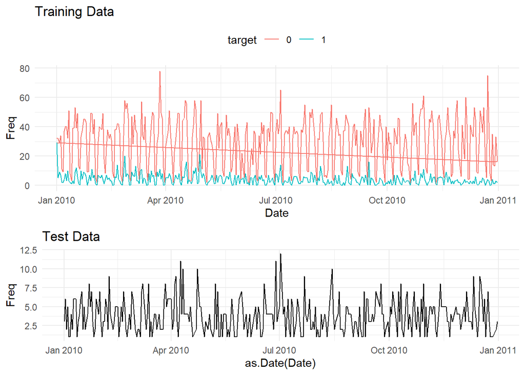

```r
sdate_dist <- table(raw_train$Policy.Start.Date, raw_train$target) %>% data.frame() %>%
  rename(Date = Var1, target = Var2)
sdate_dist$Date <- as.Date(sdate_dist$Date)

sdate_dist <- sdate_dist[-c(1:12, 377:388),] #removing dates outside of normal date range
sdate_dist2 <- table(raw_test$Policy.Start.Date) %>% data.frame() %>%
  rename(Date = Var1)

date_plt1 <- ggplot(sdate_dist, aes(x = Date, y = Freq, color = target)) +
  geom_line(group = 1) +
  theme_minimal() +
  theme(legend.position = "top") +
  labs(title = "Training Data")
date_plt2 <- ggplot(sdate_dist2, aes(x = as.Date(Date), y = Freq)) +
  geom_line(group = 1) +
  theme_minimal() +
  labs(title = "Test Data")

cowplot::plot_grid(date_plt1, date_plt2, rel_heights = c(0.6,0.4), ncol=1)
```

It looks like the number of observations are seasonal by week. There does not seem to be any distinguishable difference in the peaks and troughs across the target variable, other than a strange peak on `2010-01-01`, where the two levels almost meet. This can be confirmed in the data:

```r
sdate_dist %>% filter(Date == "2010-01-01")
```

```
##         Date target Freq
## 1 2010-01-01      0   32
## 2 2010-01-01      1   29
```

We could possibly make this into a dummy variable later. However, based on the graphs, it appears the dates as-is won’t be able to distinguish much between the levels of the target variable. Looking at the dates at a more granular level may help us glean more information from them.

```r
head(sdate_dist, n = 14)
```

```
##          Date target Freq
## 13 2010-01-01      0   32
## 14 2010-01-02      0   32
## 15 2010-01-03      0   29
## 16 2010-01-04      0   34
## 17 2010-01-05      0   11
## 18 2010-01-06      0    9
## 19 2010-01-07      0   37
## 20 2010-01-08      0   40
## 21 2010-01-09      0   40
## 22 2010-01-10      0   32
## 23 2010-01-11      0   51
## 24 2010-01-12      0    8
## 25 2010-01-13      0    3
## 26 2010-01-14      0   39
```

There is a noticeable drop during `2010-01-05` and `2010-01-06`, as well as `2010-01-12` and `2010-01-13`. We could assume that this would be the weekend, although, curiously, on the 2010 calendar, Jan. 5, 2010 is actually a Tuesday. This could either mean the dates provided in the data are slightly offset, or that the insurance office has strange hours (i.e. has shortened hours on Tuesday and Wednesday).

Are more claims filed in certain months more than others?

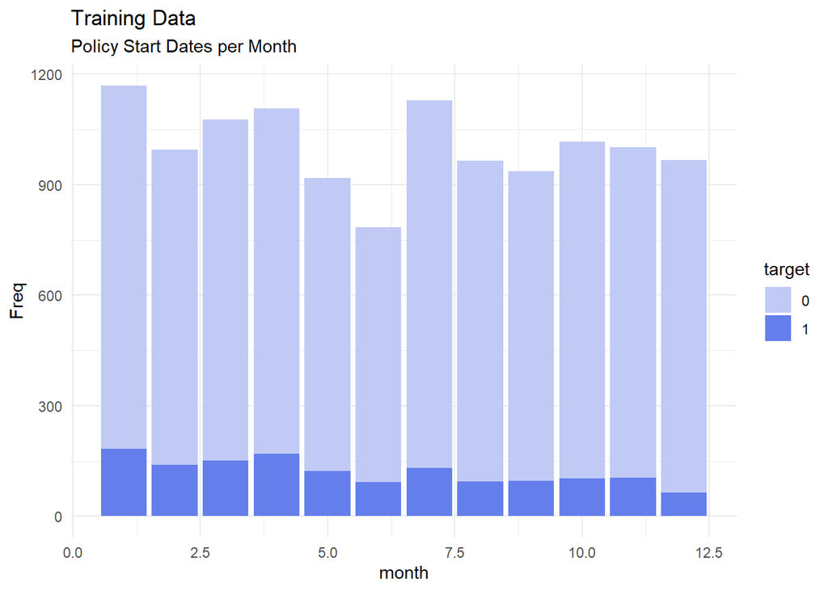

```r
sdate_dist_month <- sdate_dist %>%
  mutate(month = lubridate::month(Date)) %>%
  group_by(month, target) %>%
  summarise(Freq = sum(Freq))

ggplot(sdate_dist_month, aes(x = month, y = Freq, fill = target)) +
  geom_bar(stat = "identity") +
  theme_minimal() +
  labs(title = "Training Data", subtitle = "Policy Start Dates per Month") +
  scale_fill_manual(values = c("#C0CAF5","#647FEB"))
```

There doesn’t look to be a huge month-to-month difference between those who filed again and those who did not, other than a slight decline over time for those who did file again (`target = 1`).

## 2.3 Policy End Date

While it does not seem that there are many conclusions to draw from the policy start date, the policy end date may reveal a different trend.

```r
edate_dist <- table(raw_train$Policy.End.Date, raw_train$target) %>% data.frame() %>%
  rename(Date = Var1, target = Var2)
edate_dist$Date <- as.Date(edate_dist$Date)
#checking for outliers and removing them
edate_dist %>% filter(lubridate::year(Date) > 2012 | lubridate::year(Date) < 2009)
```

```
##          Date target Freq
## 1  2016-06-25      0    1
## 2  2016-09-06      0    1
## 3  2034-05-20      0    1
## 4  2037-08-03      0    1
## 5  2041-04-18      0    2
## 6  2016-06-25      1    0
## 7  2016-09-06      1    0
## 8  2034-05-20      1    0
## 9  2037-08-03      1    0
## 10 2041-04-18      1    0
```

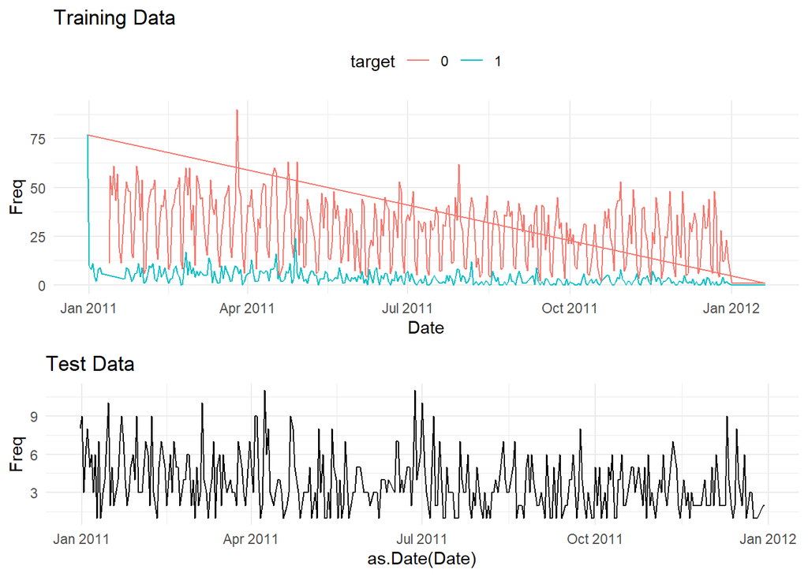

```r
edate_dist %<>% slice(-which(lubridate::year(Date) > 2012 | lubridate::year(Date) < 2009))

edate_dist <- edate_dist[-c(1:12, 377:388),] #removing dates outside of normal date range
edate_dist2 <- table(raw_test$Policy.End.Date) %>% data.frame() %>%
  rename(Date = Var1)

date_plt1 <- ggplot(edate_dist, aes(x = Date, y = Freq, color = target)) +
  geom_line(group = 1) +
  theme_minimal() +
  theme(legend.position = "top") +
  labs(title = "Training Data")
date_plt2 <- ggplot(edate_dist2, aes(x = as.Date(Date), y = Freq)) +
  geom_line(group = 1) +
  theme_minimal() +
  labs(title = "Test Data")

cowplot::plot_grid(date_plt1, date_plt2, rel_heights = c(0.6,0.4), ncol=1)
```

Similarly to the policy start date, there are a lot of policies that end on the first date (Dec 31, 2010 - one year after the strange peak on Jan 1, 2010 in `Policy.Start.Date`).

```r
edate_dist %>% arrange(-Freq) %>% top_n(10)
```

```
##          Date target Freq
## 1  2011-03-26      0   90
## 2  2010-12-31      1   77
## 3  2011-04-24      0   63
## 4  2011-04-29      0   63
## 5  2011-07-30      0   62
## 6  2011-01-15      0   61
## 7  2011-01-28      0   61
## 8  2011-02-25      0   60
## 9  2011-02-27      0   60
## 10 2011-04-16      0   60
```

Thus, there is evidence that customers who bought a plan on Jan. 1, 2010 with a end date of Dec 31, 2010 are more likely to file a claim. However, two points to consider are:

1. There are more claim-filing customers with a policy end date of Dec 31, 2010 (77) than the claim-filing customers that bought a policy on Jan 1, 2010 (29), meaning that there is no guarantee these are the same customers from start to end.
2. The proportion of claim-filing customers who represent this anomaly is still very small (77/12079). Thus, while creating a dummy variable to include this observation in the model may be worthwhile, it is not a silver bullet. It may not prove to be effective at all.

Nevertheless, we should compare the policy end dates month-by-month like we did with the policy start dates.

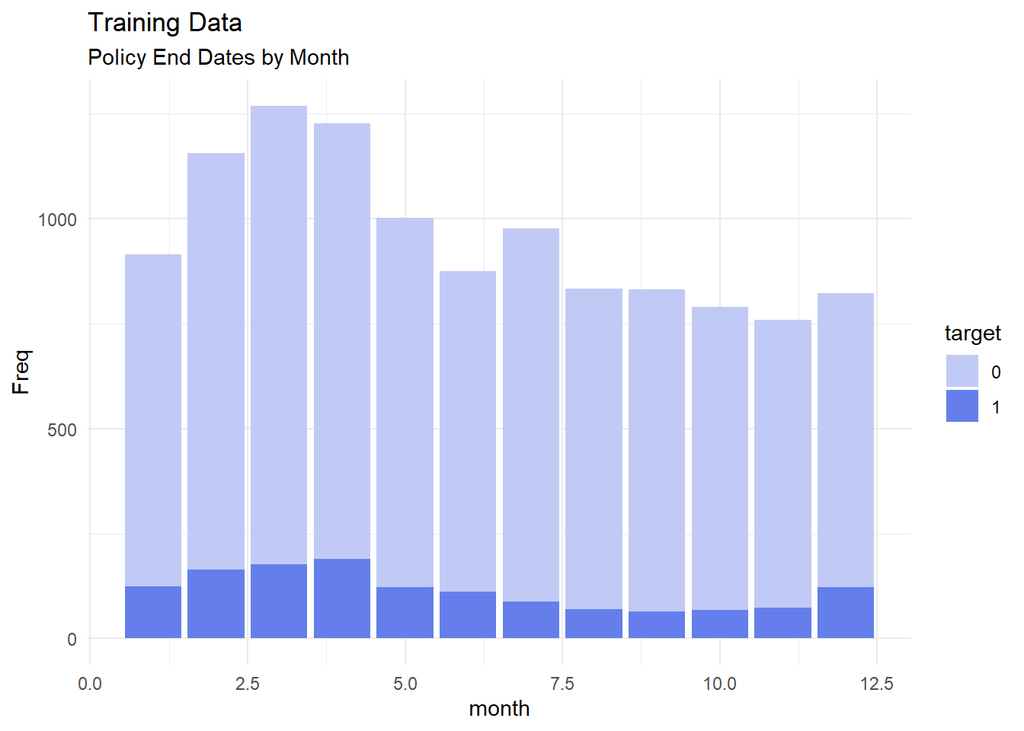

```r
edate_dist_month <- edate_dist %>%
  mutate(month = lubridate::month(Date)) %>%
  group_by(month, target) %>%
  summarise(Freq = sum(Freq))

ggplot(edate_dist_month, aes(x = month, y = Freq, fill = target)) +
  geom_bar(stat = "identity") +
  theme_minimal() +
  labs(title = "Training Data", subtitle = "Policy End Dates by Month") +
  scale_fill_manual(values = c("#C0CAF5","#647FEB"))
```

Our previous Jan 1, 2010 - Dec 31, 2010 discovery is barely noticeable here. The proportion of claim-filing customers seems to rise and fall with that of the non-claim-filing customers.

## 2.4 Age

Let’s start with a line graph to get a feel of the age distribution.

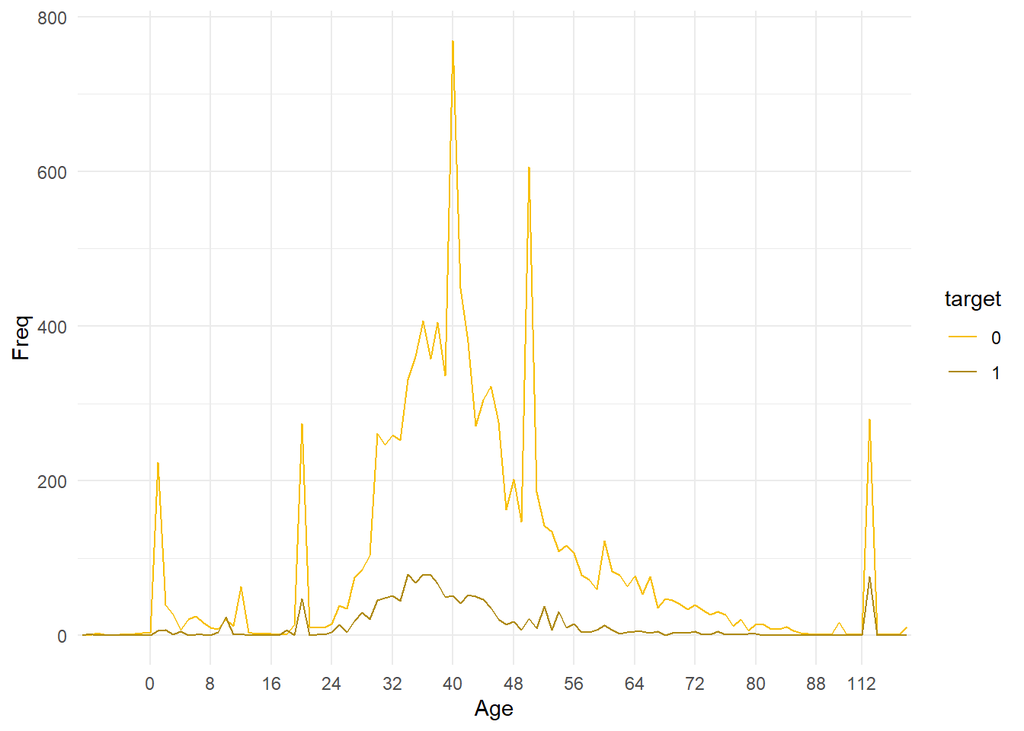

```r
age_freq <- data.frame(table(raw_train$Age, raw_train$target)) %>%
  rename(Age = Var1, target = Var2)

ggplot(age_freq, aes(Age, Freq, color = target, group = target)) +
  geom_line() +
  scale_x_discrete(breaks = seq(0,112,8)) +
  scale_color_manual(values = c("#F7BF04","#AE890F")) +
  theme_minimal()
```

When we checked for missing values earlier, there were none found for age that were labeled as `""`. However, this graph shows us that the missing values for age were just encoded differently. There are a significant number of values below and above what we would consider normal for driving age (below 16, above 102). Let’s trim the plot so we can get a better representation of the age distribution.

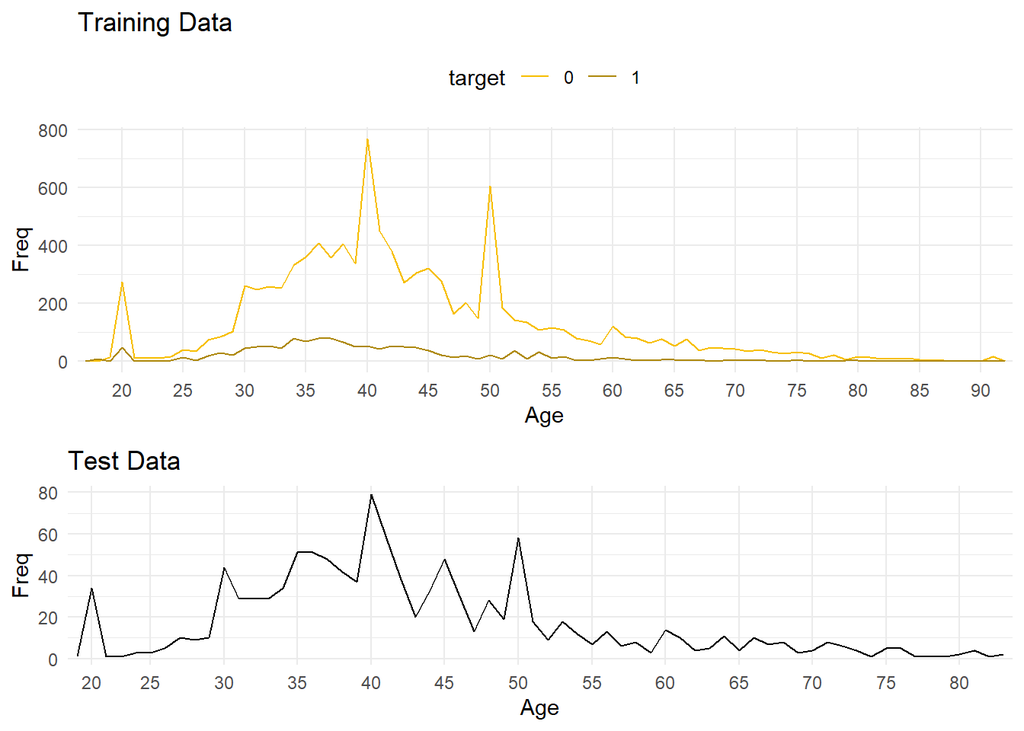

```r
normal_ages <- raw_train %>% filter(Age > 16, Age < 102)
normal_age_freq <- table(normal_ages[,c("Age", "target")]) %>%
  data.frame()

normal_ages2 <- raw_test %>% filter(Age > 16, Age < 102)
normal_age_freq2 <- table(normal_ages2$Age) %>% data.frame() %>% rename(Age = Var1)


normal_age_plot <-
  ggplot(normal_age_freq, aes(x = Age, y = Freq, color = target, group = target)) +
  geom_line() +
  scale_x_discrete(breaks = seq(15, 95, 5)) +
  scale_color_manual(values = c("#F7BF04","#AE890F")) +
  labs(title = "Training Data") +
  theme_minimal() +
  theme(legend.position = "top")

normal_age_plot2 <-
  ggplot(normal_age_freq2, aes(x = Age, y = Freq, group = 1)) +
  geom_line(stat = "identity") +
  labs(title = "Test Data") +
  scale_x_discrete(breaks = seq(15, 95, 5)) +
  theme_minimal()

cowplot::plot_grid(normal_age_plot, normal_age_plot2, rel_heights = c(0.6,0.4), ncol=1)
```

These plots more clearly show the peaks in both the training and test data at 20 (young drivers), 40, and 50 (parents’ age). In comparison, these peaks do not seem to be as prominent for those who filed an insurance claim. Thus, it seems that age will be a useful predictor variable in our model.

## 2.5 Product Name

```r
product_dist <-
  data.frame(table(raw_train$ProductName, raw_train$target)) %>%
  arrange(-Freq) %>%
  rename(ProductName = Var1, target = Var2)
product_dist
```

| ProductName | target | Freq |
| --- | --- | --- |
| Car Classic | 0 | 5411 |
| CarSafe | 0 | 3760 |
| Car Classic | 1 | 1074 |
| Customized Motor | 0 | 503 |
| Car Plus | 0 | 383 |
| CVTP | 0 | 349 |
| CarFlex | 0 | 147 |
| CVTP | 1 | 120 |
| Car Plus | 1 | 103 |
| Muuve | 1 | 65 |

[output cut: 8 more lines]

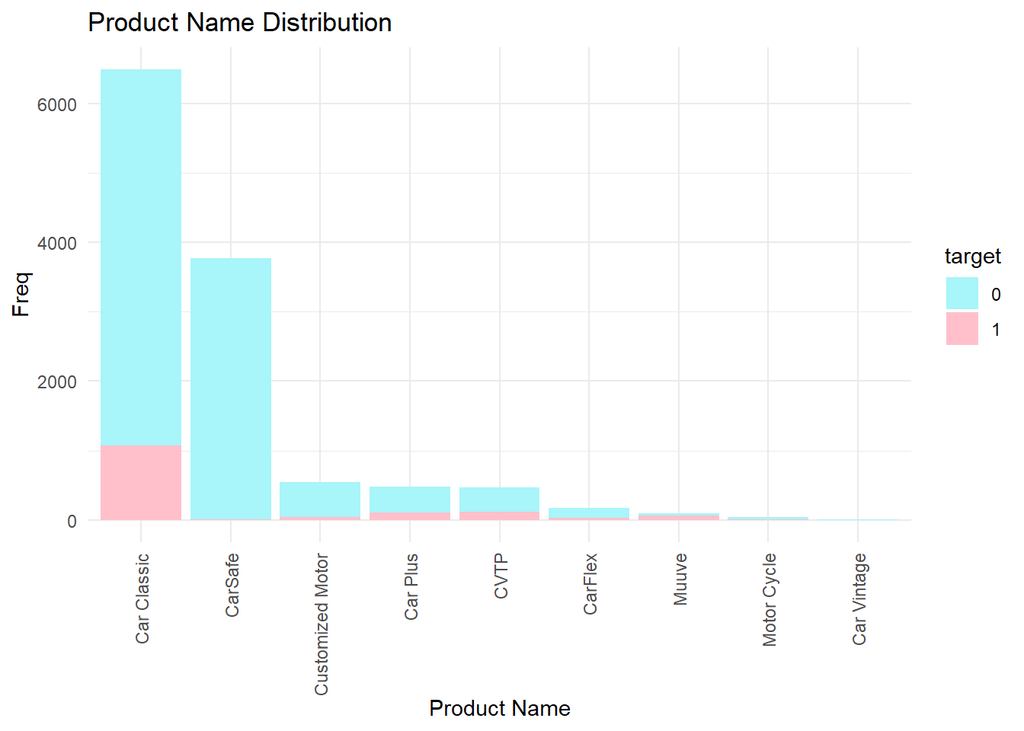

```r
ggplot(product_dist, aes(x = reorder(ProductName,-Freq), y = Freq, fill = target)) +
  geom_bar(stat = "identity") +
  labs(title = "Product Name Distribution", x = "Product Name", y = "Freq") +
  scale_fill_manual(values = c("#A8F5FA", "#FFC0CB")) +
  theme_minimal() +
  theme(axis.text.x = element_text(angle = 90, vjust = 0.5, hjust=1))
```

The bar graph above suggests that Product Name may be our most useful predictor yet. The proportional difference across the target variable for the two largest categories, `Car Classic` and `CarSafe`, is quite noticeable. There was a very low number of claims filed by those with the `CarSafe` plan.

## 2.6 Car Category

```r
data.frame(prop.table(table(raw_train$Car_Category))*100) %>% arrange(-Freq) %>% rename(Car_Category = Var1)
```

```
##               Car_Category         Freq
## 1                   Saloon 49.954466429
## 2                          30.946270387
## 3                     JEEP 16.731517510
## 4                    Truck  0.803046610
## 5                      Bus  0.447056876
## 6                 Mini Bus  0.298037917
## 7                  Pick Up  0.248364931
## 8               Motorcycle  0.140740127
## 9                 Mini Van  0.107624803
## 10                   Sedan  0.099345972
## 11                   Wagon  0.082788310
## 12 Shape Of Vehicle Chasis  0.049672986
## 13         Station 4 Wheel  0.041394155
## 14                     Van  0.024836493
## 15          CAMRY CAR HIRE  0.008278831
## 16        Pick Up > 3 Tons  0.008278831
## 17            Tipper Truck  0.008278831
```

The vast majority (~97.6%) of categories are dominated by `Saloon`, `JEEP`, and missing values. We will probably want to consolidate these into a smaller number of categories before incorporating this variable as a predictor for our model.

## 2.7 Number of Policies

```r
prop.table(table(raw_train$No_Pol))
```

```
##
##            1            2            3            4            5            6
## 0.7931120126 0.1404089743 0.0446228992 0.0170543919 0.0019869194 0.0006623065
##            7           10
## 0.0014074013 0.0007450948
```

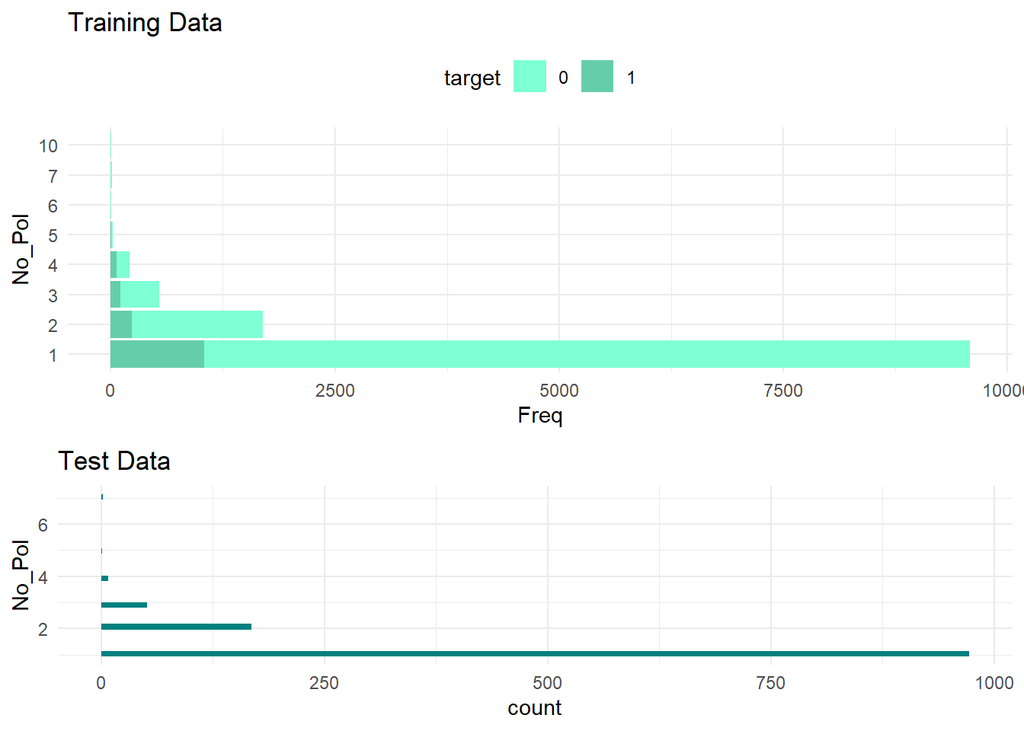

```r
pol_freq <- table(raw_train[,c("No_Pol", "target")]) %>%
  data.frame()
train_plt <-
  ggplot(pol_freq, aes(x = No_Pol, y = Freq, group = target, fill = target)) +
  geom_bar(stat = "identity") + coord_flip() +
  scale_fill_manual(values = c("#7FFFD4","#66CDAA")) +
  labs(title = "Training Data") +
  theme_minimal() +
  theme(legend.position = "top")

test_plt <-
  ggplot(raw_test, aes(x = No_Pol, fill = "#008080")) +
  geom_histogram() + coord_flip() +
  labs(title = "Test Data") +
  scale_fill_manual(values = "#008080") +
  theme_minimal() +
  theme(legend.position = "none")

cowplot::plot_grid(train_plt, test_plt, rel_heights = c(0.6,0.4), ncol=1)
```

The proportions between the train and the test data are similar, with customers with 1 policy being the most common. We’ll have to see whether it will be better for the model to bin this variable into **1 policy** and **1 or more policy** categories, or just to keep it as a numeric predictor.

## 2.8 Gender

```r
prop.table(table(raw_train$Gender))
```

```
##
##                    Entity       Female Joint Gender         Male    NO GENDER
##  0.029721003  0.022932362  0.275436708  0.018461793  0.630598559  0.005464028
##   NOT STATED          SEX
##  0.014487954  0.002897591
```

To get the most out of this category, we should bin it into 3 levels: male, female, and other. (see feature engineering section)

## 2.9 Car Color

```r
prop.table(table(raw_train$Subject_Car_Colour))*100 %>% sort()
```

```
##
##                   As Attached            Ash       B.Silver  Beige Mitalic
##   57.637221624    4.122857852    1.101084527    0.016557662    0.008278831
##          Black Black & Orange  Black & White           Blue     Blue & Red
##   15.564202335    0.016557662    0.016557662    2.988658001    0.024836493
##       Blue Sky Blue&White&Red          Brown       Burgundy      Champagne
##    0.008278831    0.008278831    0.480172200    0.008278831    0.008278831
##          Cream        D. Gold         D. Red      Dark Blue      Dark Gray
##    0.066230648    0.008278831    0.024836493    0.016557662    0.041394155
##     Dark Green      Dark Grey       Dark Red           Gold    Gray & Gray
##    0.008278831    0.016557662    0.008278831    1.432237768    0.016557662
##  Gray & Silver          Green           Grey     Light Blue     Light Gray
##    0.016557662    1.928967630    4.255319149    0.008278831    0.008278831
##    Light Green         Orange         Purple            Red    Red & Black
##    0.024836493    0.041394155    0.033115324    2.077986588    0.016557662
##     Red & Blue    Red & White   Red & Yellow         Silver          White
##    0.008278831    0.033115324    0.008278831    4.586472390    2.425697492
##   White & Blue    White & Red White & Yellow           Wine         Yellow
##    0.041394155    0.016557662    0.008278831    0.736815962    0.066230648
## Yellow & White
##    0.008278831
```

Car color doesn’t seem to be very useful. About 62% of the data is missing (if we consider `As Attached` as a missing value). In addition, there are several remaining color categories, some of which have more than one color, making it hard to group them.

## 2.10 Car Make

```r
table(raw_train$Subject_Car_Make) %>% as.data.frame() %>%
  arrange(desc(Freq))%>% mutate(pct = (Freq/nrow(raw_train))*100)
```

| Var1 | Freq | pct |
| --- | --- | --- |
| TOYOTA | 4975 | 41.187184370 |
|  | 2476 | 20.498385628 |
| Honda | 1043 | 8.634820763 |
| Lexus | 604 | 5.000413942 |
| Mercedes | 521 | 4.313270966 |
| Hyundai | 457 | 3.783425780 |
| Kia | 341 | 2.823081381 |
| Ford | 283 | 2.342909181 |
| Nissan | 249 | 2.061428926 |
| Volkswagen | 122 | 1.010017386 |

[output cut: 65 more lines]

**Car make** appears to be more useful. Only about 20% of the values are missing. Also, there are several different ways we can bin these categories: by country/region of origin, or whether they are considered to be a “luxury” vehicle. We can also see how this variable interacts with car category.

## 2.11 City

```r
table(raw_train$LGA_Name) %>% as.data.frame() %>%
  arrange(desc(Freq)) %>% mutate(pct = (Freq/nrow(raw_train))*100)
```

| Var1 | Freq | pct |
| --- | --- | --- |
|  | 6476 | 53.613709744 |
| Victoria Island | 1162 | 9.620001656 |
| Ikeja | 401 | 3.319811243 |
| Surulere | 288 | 2.384303336 |
| Abuja Municipal | 232 | 1.920688799 |
| Lagos Mainland | 222 | 1.837900488 |
| Lagos Island | 221 | 1.829621657 |
| Eti-Osa | 217 | 1.796506333 |
| Lekki | 207 | 1.713718023 |
| Lagos | 168 | 1.390843613 |

[output cut: 249 more lines]

More than half the variables are missing for this variable. We could possibly bin this variable into three categories: Missing, Other, and Lagos (Victoria Island, Lagos Mainland/Island, and others are all part of Lagos state in Nigeria.)

## 2.12 State

```r
table(raw_train$State) %>% as.data.frame() %>%
  arrange(desc(Freq)) %>% mutate(pct = (Freq/nrow(raw_train))*100)
```

| Var1 | Freq | pct |
| --- | --- | --- |
|  | 6488 | 53.713055717 |
| Lagos | 3186 | 26.376355659 |
| Benue | 626 | 5.182548224 |
| Abuja-Municipal | 232 | 1.920688799 |
| Eti-Osa | 217 | 1.796506333 |
| Ibeju-Lekki | 123 | 1.018296217 |
| Ogun | 89 | 0.736815962 |
| Oshodi-Isolo | 89 | 0.736815962 |
| Delta | 86 | 0.711979468 |
| Obia-Akpor | 85 | 0.703700637 |

[output cut: 102 more lines]

It makes sense that the state data would be similar to the city data in terms of percentage. Lagos is a lot better represented in this category, and we’d probably get a similar proportion if we binned all the cities in Lagos state. In other words, binning this `State` variable into Missing, Other, and Lagos categories would likely yield similar proportions if we were to do it for the `City` variable.

## 2.13 Summary

After examining each predictor variable, it looks like none will be used as-is. Thus, we will have to manipulate the variables and create new ones to get the most use out of them. In the next section, we’ll do the following:

- Trim the `Age` range and either impute, eliminate, or adjust the outliers
- Create a policy length variable and examine its distribution across the target variable
- Create bins for `Gender`, `ProductName`,`Car_Category`, `Subject_Car_Make`,`City`,`State`, and possibly `No_Pol`
- Create luxury and country of import variables from `Subject_Car_Make`
- Encode all categorical variables as numeric using methods like target mean encoding and one-hot encoding
- Create interaction terms from the encoded variables

# 3 Feature Engineering

## 3.1 Age

How can we encode the outliers for `Age` (younger than 16, older than 102)?

- We could label them `NA`, then impute those values with the mean, median, mode, or the predicted results from a k-nearest neighbors or regression model
- Remove all the rows with missing `Age` values from the dataset
- Label them all as -1
- Bin `Age` into categorical variables (e.g. young drivers would be 20-25), then have a separate category for missing values

**Note**: Each of these methods was attempted and ran with a random forest model. Imputing missing values with -1 worked best.

```r
raw_train$Age <- ifelse(raw_train$Age < 16 | raw_train$Age > 102, -1, raw_train$Age)
raw_test$Age <- ifelse(raw_test$Age < 16 | raw_test$Age > 102, -1, raw_test$Age)
```

## 3.2 Policy Length

Since we have `Policy.Start.Date` and `Policy.End.Date`, we can take their difference and create a new variable, which we’ll call `policy_length`.

```r
raw_train %<>% mutate(policy_length = as.numeric(as.Date(raw_train$Policy.End.Date) - as.Date(raw_train$Policy.Start.Date)))

raw_test %<>% mutate(policy_length = as.numeric(as.Date(raw_test$Policy.End.Date) - as.Date(raw_test$Policy.Start.Date)))

pol_length_freq <- data.frame(table(raw_train$policy_length, raw_train$target)) %>%
  rename(PolicyLength = Var1, target = Var2)

pol_length_freq %>% arrange(-Freq)
```

| PolicyLength | target | Freq |
| --- | --- | --- |
| 364 | 0 | 8503 |
| 364 | 1 | 1039 |
| 363 | 0 | 512 |
| 181 | 0 | 144 |
| 365 | 0 | 73 |
| 182 | 0 | 58 |
| 180 | 0 | 55 |
| 363 | 1 | 54 |
| 91 | 0 | 47 |
| 362 | 0 | 43 |

[output cut: 592 more lines]

It seems that the majority of policies are either year or half-year long. We can bin policies into these ranges, then plot the distribution to see if there is any noticeable difference between the target variable levels.

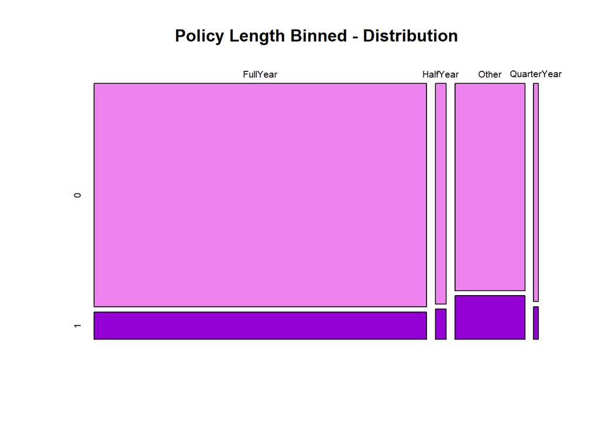

```r
raw_train$PolicyLengthBin <-
  case_when(raw_train$policy_length %in% 364:365 ~ "FullYear",
            raw_train$policy_length %in% 178:182 ~ "HalfYear",
            raw_train$policy_length %in% 89:93 ~ "QuarterYear",
            TRUE ~ "Other")

pol_length_freq2 <- table(raw_train$PolicyLengthBin, raw_train$target)

graphics::mosaicplot(pol_length_freq2, col = c("#EE82EE","#9400D3"),
                     main = "Policy Length Binned - Distribution")
```

## 3.3 Binning

By creating bins for some of the categorical variables, we can make categories useful that would not be otherwise by including them as part of a larger group.

### 3.3.1 Gender

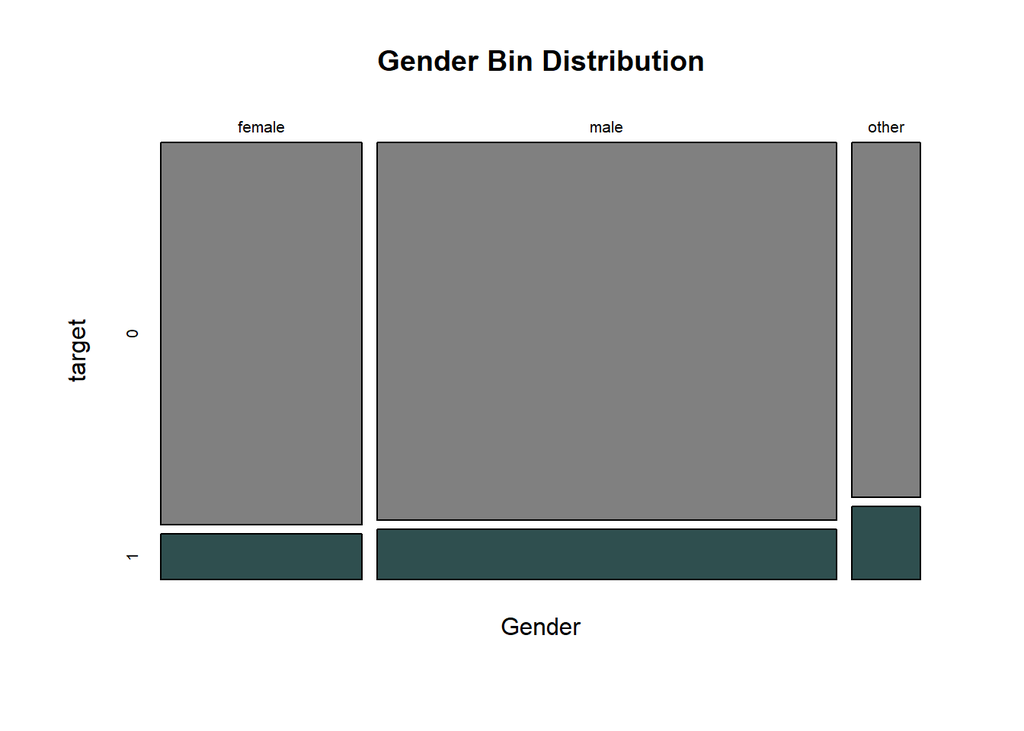

```r
raw_train$Gender_Bin <-
  case_when(raw_train$Gender == "Male" ~ "male",
            raw_train$Gender == "Female" ~ "female",
            TRUE ~ "other")

raw_test$Gender_Bin <-
  case_when(raw_test$Gender == "Male" ~ "male",
            raw_test$Gender == "Female" ~ "female",
            TRUE ~ "other")

gender_bin_freq <- table(raw_train$Gender_Bin, raw_train$target)

graphics::mosaicplot(gender_bin_freq, col = c("#808080","#2F4F4F"),
                     main = "Gender Bin Distribution",
                     xlab = "Gender", ylab = "target")
```

The proportions between male and female policy buyers is almost the same. However, the `other` category has a larger proportion of claim-filing customers, so we can plan to test out this newly created variable in our model.

### 3.3.2 Number of Policies

We can do something similar for the `No_Pol` predictor. Sometimes a level of detail can be lost when converting a numeric variable to a categorical one, but we can try both and see which is better for model performance.

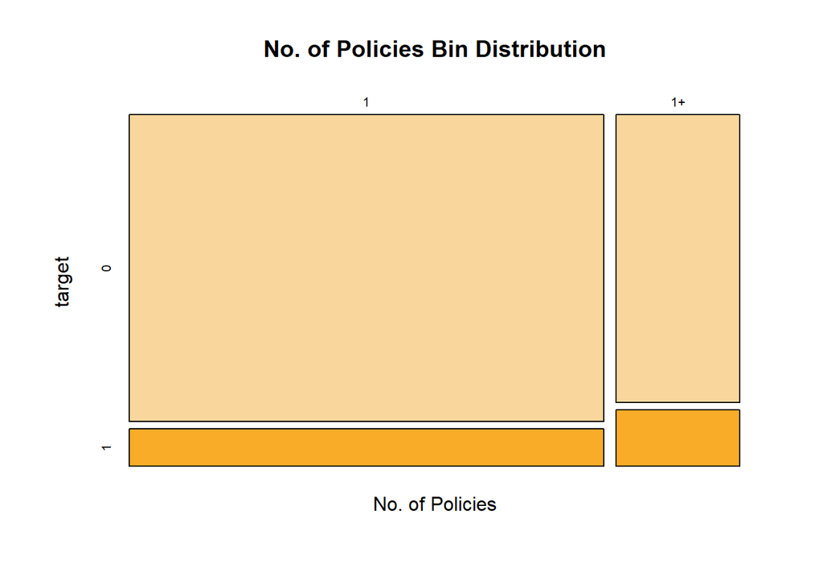

```r
raw_train$No_Pol_Bin <-
  case_when(raw_train$No_Pol == 1 ~ "1",
            TRUE ~ "1+")
raw_test$No_Pol_Bin <-
  case_when(raw_test$No_Pol == 1 ~ "1",
            TRUE ~ "1+")

gender_bin_freq <- table(raw_train$No_Pol_Bin, raw_train$target)

graphics::mosaicplot(gender_bin_freq, col = c("#F9D79C","#F9AC28"),
                     main = "No. of Policies Bin Distribution",
                     xlab = "No. of Policies", ylab = "target")
```

The mosaic plot shows a noticeable difference in proportion, so we should consider `No_Pol_Bin` as a possibly useful predictor.

### 3.3.3 Product Name

We discovered during the Product Name EDA that the proportion of customers who bought `CarSafe` was significantly different across the target variable. As a result, when binning this variable, we should keep it as its own category (as well as the most popular product, `Car Classic`). The rest can be grouped into a fall-through category we’ll call `other`.

```r
raw_train$Product_Bin <-
  case_when(raw_train$ProductName == "Car Classic" ~ "CarClassic",
            raw_train$ProductName == "CarSafe" ~ "CarSafe",
            TRUE ~ "other")

raw_test$Product_Bin <-
  case_when(raw_test$ProductName == "Car Classic" ~ "CarClassic",
            raw_test$ProductName == "CarSafe" ~ "CarSafe",
            TRUE ~ "other")

prop.table(table(raw_train$Product_Bin, raw_train$target))
```

```
##
##                        0           1
##   CarClassic 0.447967547 0.088914645
##   CarSafe    0.311284047 0.001159036
##   other      0.120291415 0.030383310
```

```r
prop.table(table(raw_test$Product_Bin))
```

```
##
## CarClassic    CarSafe      other
##  0.5465890  0.3161398  0.1372712
```

### 3.3.4 City and State

As discussed during the EDA, we can bin `City` and `State` into three main categories: missing, other, and Lagos. After that, we can compare their proportions to see if both are worth including as separate predictors. I did some additional research to determine if certain cities or states were within Lagos.

```r
raw_train$State_Bin <-
  case_when(raw_train$State == "" ~ "missing",
            raw_train$State %in%
              c("Lagos","Amu-Odofin", "Port-Harcourt",
                "Eti-Osa","Ibeju-Lekki", "Oshodi-Isolo")~ "Lagos",
            TRUE ~ "other")


raw_test$State_Bin <-
  case_when(raw_test$State == "" ~ "missing",
            raw_test$State %in%
              c("Lagos","Amu-Odofin", "Port-Harcourt",
                "Eti-Osa","Ibeju-Lekki", "Oshodi-Isolo")~ "Lagos",
            TRUE ~ "other")


#city
raw_train$City_Bin <-
  case_when(raw_train$LGA_Name == "" ~ "missing",
            raw_train$LGA_Name %in%
              c("Lagos","Victoria Island", "Port Harcourt",
                "Eti-Osa","Ibeju/Lekki", "Oshodi-Isolo",
                "Lagos Mainland", "Lagos Island")~ "Lagos",
            TRUE ~ "other")

raw_test$City_Bin <-
  case_when(raw_test$LGA_Name == "" ~ "missing",
            raw_test$LGA_Name %in%
              c("Lagos","Victoria Island", "Port Harcourt","Lekki",
                "Eti-Osa","Ibeju/Lekki", "Oshodi-Isolo",
                "Lagos Mainland", "Lagos Island")~ "Lagos",
            TRUE ~ "other")

prop.table(table(raw_train$State_Bin))*100
```

```
##
##    Lagos  missing    other
## 30.20945 53.71306 16.07749
```

```r
prop.table(table(raw_train$City_Bin))*100
```

```
##
##    Lagos  missing    other
## 18.61909 53.61371 27.76720
```

The EDA for state revealed that ~26% of customers bought their policy in Lagos. The 18.6% for Lagos State in the `City_Bin` is lower than that because I must have misclassified some of the cities into the `other` category. Since the binning for these two variables have different proportions for Lagos/other, we can keep them as separate variables.

### 3.3.5 Car Category

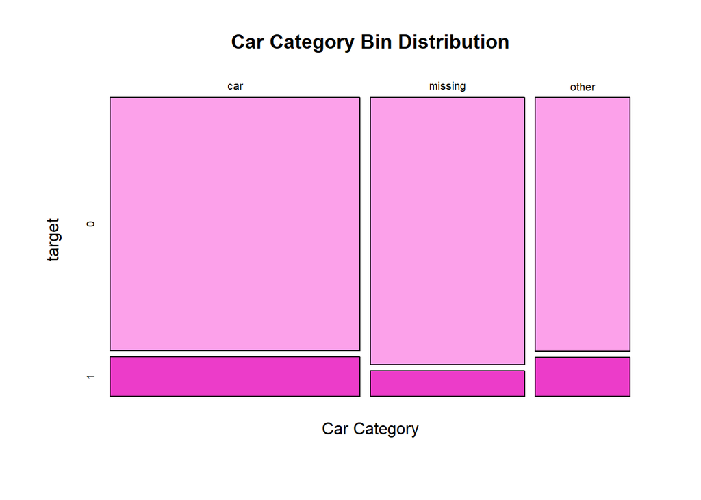

```r
raw_train$Car_Category_Bin <-
  case_when(raw_train$Car_Category == "" ~ "missing",
            raw_train$Car_Category %in%
              c("Saloon", "Sedan", "CAMRY CAR HIRE") ~ "car",
            TRUE ~ "other")
raw_train$Car_Category_Bin2 <-
  case_when(raw_train$Car_Category == "" ~ "missing",
            raw_train$Car_Category == "JEEP" ~ "Jeep",
            raw_train$Car_Category %in%
              c("Saloon", "Sedan", "CAMRY CAR HIRE") ~ "car",
            TRUE ~ "other")


raw_test$Car_Category_Bin <-
  case_when(raw_test$Car_Category == "" ~ "missing",
            raw_test$Car_Category %in%
              c("Saloon", "Sedan", "CAMRY CAR HIRE") ~ "car",
            TRUE ~ "other")

carcat_bin_freq <- table(raw_train$Car_Category_Bin, raw_train$target)
carcat_bin_freq2 <- table(raw_train$Car_Category_Bin2, raw_train$target)


graphics::mosaicplot(carcat_bin_freq, col = c("#FCA1EA","#EC3CC9"),
                     main = "Car Category Bin Distribution",
                     xlab = "Car Category", ylab = "target")
```

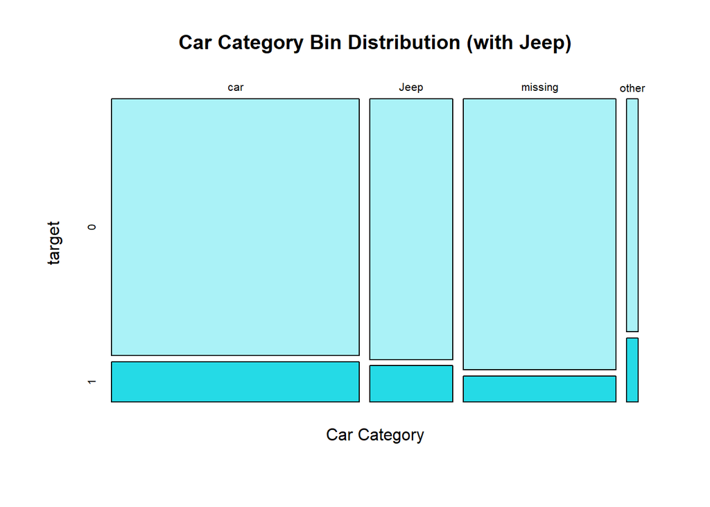

```r
graphics::mosaicplot(carcat_bin_freq2, col = c("#AAF2F7","#25DAE6"),
                     main = "Car Category Bin Distribution (with Jeep)",
                     xlab = "Car Category", ylab = "target")
```

Our EDA for car category revealed that `Saloon` was ~50% of customers` car category. Without running the model, we can’t say for sure whether keeping Jeep as its own category or combining it with `other` will be best.

**Note**: after running a few models, it became clear that combining Jeep with the other car categories improved model performance.

## 3.4 Car Make

### 3.4.1 Brand Popularity

After doing a bit of research, it became clear that Toyota is the overwhelmingly popular car brand in Nigeria (specifically the Corolla, Sienna, Camry, and Highlander). This is consistent with our data. Range Rover, Honda, Lexus, Volkswagen, and Mercedes-Benz were listed as the most common brands.

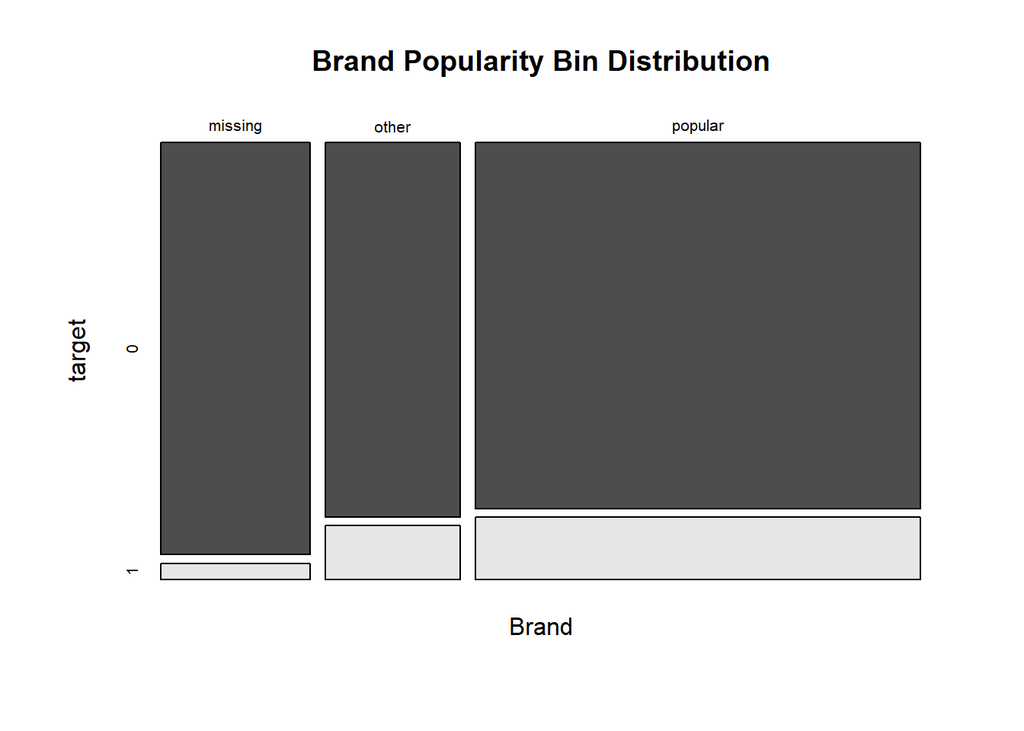

```r
raw_train$Popularity_Bin <-
  case_when(raw_train$Subject_Car_Make %in%
              c("TOYOTA", "Honda", "Volkswagen",
                "Range Rover","Lexus","Mercedes")~ "popular",
            raw_train$Subject_Car_Make == "" ~ "missing",
            TRUE ~ "other")

raw_test$Popularity_Bin <-
  case_when(raw_test$Subject_Car_Make %in%
              c("TOYOTA", "Honda", "Volkswagen",
                "Range Rover","Lexus","Mercedes")~ "popular",
            raw_test$Subject_Car_Make == "" ~ "missing",
            TRUE ~ "other")

pop_bin_freq <- table(raw_train$Popularity_Bin, raw_train$target)

graphics::mosaicplot(pop_bin_freq, col= TRUE,
                     main = "Brand Popularity Bin Distribution",
                     xlab = "Brand", ylab = "target")
```

The proportions across the target variable don’t seem too different for popular and non-popular brands. However, having the missing values as their own category looks to be useful in improving model performance.

### 3.4.2 Luxury Brands

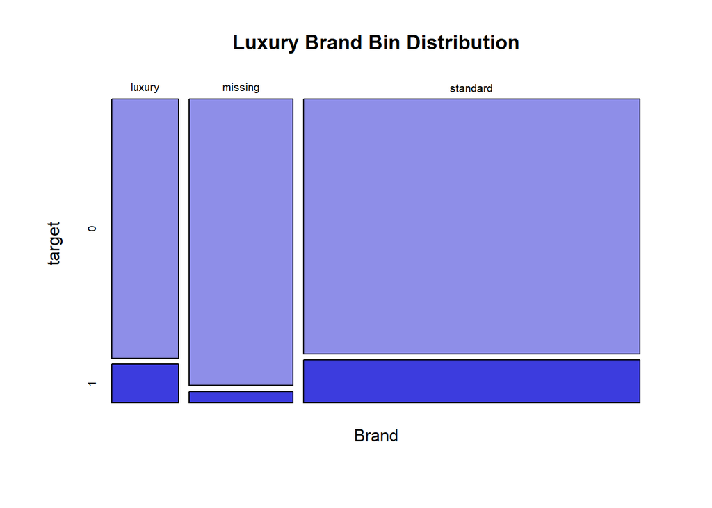

```r
raw_train$Luxury_Bin <-
  case_when(raw_train$Subject_Car_Make %in%
              c("TOYOTA", "Honda", "Hyundai","Kia","Ford",
                "Nissan", "Iveco", "Range Rover", "Mitsubishi",
                "Land Rover", "Mazda", "Mack", "Infiniti",
                "Chevrolet", "DAF", "Jeep", "Skoda", "Scania",
                "Isuzu","Suzuki", "Opel", "Dodge","Land Rover.",
                "GAC", "GMC", "Man", "Subaru", "LIBERTY", "MINI COOPER",
                "Astra", "Black","FOTON", "Fiat", "Grand Cherokee",
                "Hummer", "Innson", "Seat", "Wrangler Jeep", "ABG",
                "Ashok Leyland", "Bajaj", "BRILLIANCE", "Buik", "CHANGAN",
                "COMMANDER", "Geely", "Howo", "Jincheng", "KA", "Lincoln",
                "MG", "Motorcycle", "Raston", "REXTON", "Tata", "Yamaha",
                "ZOYTE")~ "standard",
            raw_train$Subject_Car_Make == "" ~ "missing",
            TRUE ~ "luxury")

raw_test$Luxury_Bin <-
  case_when(raw_test$Subject_Car_Make %in%
              c("TOYOTA", "Honda", "Hyundai","Kia","Ford",
                "Nissan", "Iveco", "Range Rover", "Mitsubishi",
                "Land Rover", "Mazda", "Mack", "Infiniti",
                "Chevrolet", "DAF", "Jeep", "Skoda", "Scania",
                "Isuzu","Suzuki", "Opel", "Dodge","Land Rover.",
                "GAC", "GMC", "Man", "Subaru", "LIBERTY", "MINI COOPER",
                "Astra", "Black","FOTON", "Fiat", "Grand Cherokee",
                "Hummer", "Innson", "Seat", "Wrangler Jeep", "ABG",
                "Ashok Leyland", "Bajaj", "BRILLIANCE", "Buik", "CHANGAN",
                "COMMANDER", "Geely", "Howo", "Jincheng", "KA", "Lincoln",
                "MG", "Motorcycle", "Raston", "REXTON", "Tata", "Yamaha",
                "ZOYTE")~ "standard",
            raw_test$Subject_Car_Make == "" ~ "missing",
            TRUE ~ "luxury")

lux_bin_freq <- table(raw_train$Luxury_Bin, raw_train$target)

graphics::mosaicplot(lux_bin_freq, col= c("#8E8EE8","#3C3CDE"),
                     main = "Luxury Brand Bin Distribution",
                     xlab = "Brand", ylab = "target")
```

Similarly, feature engineering a luxury variable doesn’t seem that it brings out any hidden trend in the target variable, other than that the missing values have a signficantly lower proportions of customers who filed a claim (just like the brand popularity).

### 3.4.3 Standard Binning

For standard binning, we’ll give the most frequent car categories their own bin, then combine the rest into an “other” category. We found during the Car Make EDA that `TOYOTA` was the most common at ~41%, followed by missing at 20% and Honda at 8%.

**Note**: different combinations of the third through seventh ranked cars were used as part of the `Brand_Bin` variable and ran through the model. The model performed best when the brands were binned into Toyota, Honda, missing, and other.

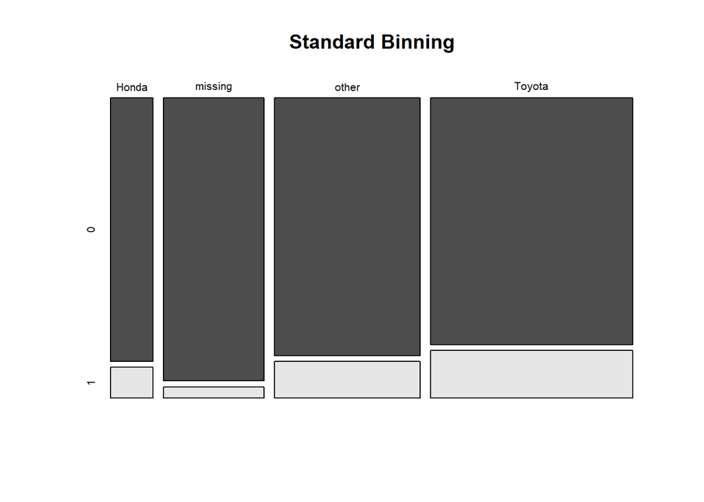

```r
raw_train$Brand_Bin <-
  case_when(raw_train$Subject_Car_Make %in% c("TOYOTA") ~ "Toyota",
            raw_train$Subject_Car_Make %in% c("Honda") ~ "Honda",
            #raw_train$Subject_Car_Make == "Lexus" ~ "Lexus",
            # raw_train$Subject_Car_Make == "Hyundai" ~ "Hyundai",
            # raw_train$Subject_Car_Make == "Ford" ~ "Ford",
            # raw_train$Subject_Car_Make == "Nissan" ~ "Nissan",
            # raw_train$Subject_Car_Make == "Mercedes" ~ "Mercedes",
            raw_train$Subject_Car_Make == "" ~ "missing",
            TRUE ~ "other")

cat.table <- table(raw_train$Brand_Bin, raw_train$target)
graphics::mosaicplot(cat.table, color = T, las = 0, main = "Standard Binning")
```

```r
raw_test$Brand_Bin <-
  case_when(raw_test$Subject_Car_Make %in% c("TOYOTA") ~ "Toyota",
            raw_test$Subject_Car_Make == "Honda" ~ "Honda",
            #raw_test$Subject_Car_Make == "Lexus" ~ "Lexus",
            # raw_test$Subject_Car_Make == "Hyundai" ~ "Hyundai",
            # raw_test$Subject_Car_Make == "Ford" ~ "Ford",
            # raw_test$Subject_Car_Make == "Nissan" ~ "Nissan",
            # raw_test$Subject_Car_Make == "Mercedes" ~ "Mercedes",
            raw_test$Subject_Car_Make == "" ~ "missing",
            TRUE ~ "other")
```

## 3.5 Encoding Categorical Variables

Why do it? - Able to create interaction terms - Can examine correlations between variables - More suited for model building. Many algorithms (like xgboost) will only work with all numeric variables

**Note**: I attempted to encode the variables two different ways: one-hot encoding (i.e. creating dummy variables) and target mean encoding. The latter better improved model performance, so I will be giving a more detailed explanation of that process.

I intentionally omitted `PolicyLengthBin` because it was dominated by policies that were for the full year.

```r
tme <- function(var, new.name){
    raw_train %>%
        group_by({{var}}) %>%
        mutate("{{new.name}}" := mean(target)) %>%
    data.frame()
}

raw_train <- tme(Gender_Bin, gender_tm)
raw_train <- tme(No_Pol_Bin, pol_tm)
raw_train <- tme(Car_Category_Bin, carcat_tm)
raw_train <- tme(State_Bin, state_tm)
raw_train <- tme(City_Bin, city_tm)
raw_train <- tme(Popularity_Bin, popularity_tm)
raw_train <- tme(Brand_Bin, brand_tm)
raw_train <- tme(Luxury_Bin, luxury_tm)
raw_train <- tme(Product_Bin, product_tm)

str(raw_train)
```

```
## 'data.frame':    12079 obs. of  35 variables:
##  $ ID                    : chr  "ID_0040R73" "ID_0046BNK" "ID_005QMC3" "ID_0079OHW" ...
##  $ Policy.Start.Date     : chr  "2010-05-14" "2010-11-29" "2010-03-21" "2010-08-21" ...
##  $ Policy.End.Date       : chr  "2011-05-13" "2011-11-28" "2011-03-20" "2011-08-20" ...
##  $ Gender                : chr  "Male" "Female" "Male" "Male" ...
##  $ Age                   : num  30 79 43 -1 20 37 40 43 71 58 ...
##  $ First.Transaction.Date: chr  "2010-05-14" "2010-11-29" "2010-03-21" "2010-08-21" ...
##  $ No_Pol                : int  1 1 1 1 3 2 3 1 2 1 ...
##  $ Car_Category          : chr  "Saloon" "JEEP" "Saloon" "" ...
##  $ Subject_Car_Colour    : chr  "Black" "Grey" "Red" "" ...
##  $ Subject_Car_Make      : chr  "TOYOTA" "TOYOTA" "TOYOTA" "" ...
##  $ LGA_Name              : chr  "" "" "" "" ...
##  $ State                 : chr  "" "" "" "" ...
##  $ ProductName           : chr  "Car Classic" "Car Classic" "Car Classic" "CarSafe" ...
##  $ target                : int  0 1 0 0 1 0 0 0 0 0 ...
```

[output cut: 21 more lines]

```r
tme2 <- function(var, new.name){
    raw_train %>%
        group_by({{var}}) %>%
        summarise("{{new.name}}" := mean(target))
}
raw_test <- left_join(raw_test,tme2(Gender_Bin, gender_tm))
raw_test <- left_join(raw_test,tme2(No_Pol_Bin, pol_tm))
raw_test <- left_join(raw_test,tme2(Car_Category_Bin, carcat_tm))
raw_test <- left_join(raw_test,tme2(State_Bin, state_tm))
raw_test <- left_join(raw_test,tme2(City_Bin, city_tm))
raw_test <- left_join(raw_test,tme2(Popularity_Bin, popularity_tm))
raw_test <- left_join(raw_test,tme2(Brand_Bin, brand_tm))
raw_test <- left_join(raw_test,tme2(Luxury_Bin, luxury_tm))
raw_test <- left_join(raw_test,tme2(Product_Bin, product_tm))


str(raw_test)
```

```
## 'data.frame':    1202 obs. of  32 variables:
##  $ ID                    : chr  "ID_01QM0NU" "ID_024NJLZ" "ID_02NOVWQ" "ID_02VSP68" ...
##  $ Policy.Start.Date     : chr  "2010-10-23" "2010-10-14" "2010-08-29" "2010-06-13" ...
##  $ Policy.End.Date       : chr  "2011-10-22" "2011-10-13" "2011-08-28" "2011-06-12" ...
##  $ Gender                : chr  "Female" "Male" "Female" "Female" ...
##  $ Age                   : num  46 32 45 58 -1 64 -1 35 22 38 ...
##  $ First.Transaction.Date: chr  "2010-10-23" "2010-10-14" "2010-08-29" "2010-06-13" ...
##  $ No_Pol                : int  1 1 2 1 1 2 1 1 1 3 ...
##  $ Car_Category          : chr  "" "" "Saloon" "Saloon" ...
##  $ Subject_Car_Colour    : chr  "" "" "Black" "" ...
##  $ Subject_Car_Make      : chr  "Ford" "" "Honda" "TOYOTA" ...
##  $ LGA_Name              : chr  "Abuja Municipal" "Kosofe" "Wuse 11" "" ...
##  $ State                 : chr  "Abuja-Municipal" "Benue" "Abuja" "" ...
##  $ ProductName           : chr  "Car Classic" "Car Classic" "Car Classic" "CarSafe" ...
##  $ policy_length         : num  364 364 364 364 364 276 364 364 364 364 ...
```

[output cut: 18 more lines]

Now we can create a subset of the data with only numeric predictors. Since we binned `No_Pol` into `pol_tm`, we should remove the original variable for now. Also, `state_tm` and `city_tm` are almost the same variable:

```r
cor(raw_train$city_tm,raw_train$state_tm)
```

```
## [1] 0.9967914
```

So we will remove `city_tm`, as it had more values in the other category.

```r
sub_train <- raw_train %>% select_if(is.numeric) %>% select(-No_Pol, -city_tm)
sub_test <- raw_test %>% select_if(is.numeric) %>% select(-No_Pol, -city_tm)


str(sub_train)
```

```
## 'data.frame':    12079 obs. of  11 variables:
##  $ Age          : num  30 79 43 -1 20 37 40 43 71 58 ...
##  $ target       : int  0 1 0 0 1 0 0 0 0 0 ...
##  $ policy_length: num  364 364 364 364 124 364 364 364 364 364 ...
##  $ gender_tm    : num  0.118 0.108 0.118 0.118 0.172 ...
##  $ pol_tm       : num  0.109 0.109 0.109 0.109 0.164 ...
##  $ carcat_tm    : num  0.1356 0.1338 0.1356 0.0877 0.0877 ...
##  $ state_tm     : num  0.078 0.078 0.078 0.078 0.167 ...
##  $ popularity_tm: num  0.1462 0.1462 0.1462 0.0384 0.0384 ...
##  $ brand_tm     : num  0.1618 0.1618 0.1618 0.0384 0.0384 ...
##  $ luxury_tm    : num  0.144 0.144 0.144 0.0384 0.0384 ...
##  $ product_tm   : num  0.16561 0.16561 0.16561 0.00371 0.20165 ...
```

```r
str(sub_test)
```

```
## 'data.frame':    1202 obs. of  10 variables:
##  $ Age          : num  46 32 45 58 -1 64 -1 35 22 38 ...
##  $ policy_length: num  364 364 364 364 364 276 364 364 364 364 ...
##  $ gender_tm    : num  0.108 0.118 0.108 0.108 0.172 ...
##  $ pol_tm       : num  0.109 0.109 0.164 0.109 0.109 ...
##  $ carcat_tm    : num  0.0877 0.0877 0.1356 0.1356 0.1356 ...
##  $ state_tm     : num  0.174 0.174 0.174 0.078 0.167 ...
##  $ popularity_tm: num  0.1265 0.0384 0.1462 0.1462 0.1265 ...
##  $ brand_tm     : num  0.1244 0.0384 0.1045 0.1618 0.1244 ...
##  $ luxury_tm    : num  0.144 0.0384 0.144 0.144 0.144 ...
##  $ product_tm   : num  0.16561 0.16561 0.16561 0.00371 0.16561 ...
```

We can create a correlation matrix to examine the relationships between the newly created numeric predictors.

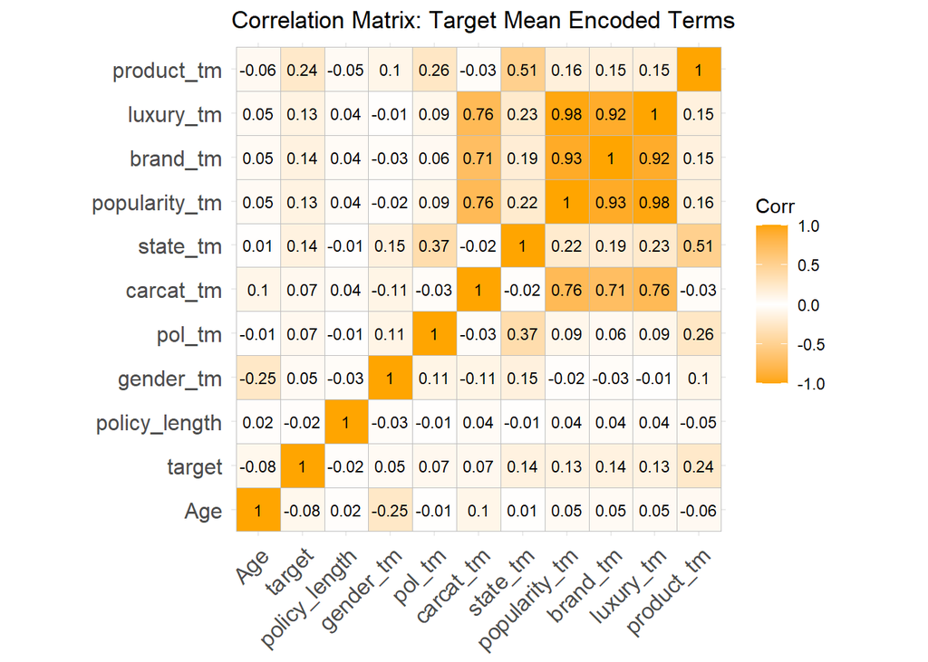

```r
cor_train <- cor(sub_train)

ggcorrplot::ggcorrplot(cor_train, colors = c("orange","white","orange"), lab = TRUE,
                       lab_size = 3,
                       title = "Correlation Matrix: Target Mean Encoded Terms")
```

One clear feature of the plot is that `luxury_tm`, `brand_tm`, and `popularity_tm` are highly correlated. This is expected, as they were all variables created from the values of `Subject_Car_Make`. Additionally, correlations of 0.76, 0.71, and 0.76 respectively with `carcat_tm` is not surprising, as we would expect certain car brands to specialize in certain car types (e.g. Toyota produces more saloons/cars than jeeps, SUVs, or trucks).

`state_tm` has a moderate positive correlation with `product_tm` (0.51). The reason for this is not apparent. Maybe a table will be able to explain more.

```r
table(raw_train$State_Bin, raw_train$Product_Bin)
```

```
##
##           CarClassic CarSafe other
##   Lagos         2416     208  1025
##   missing       2605    3438   445
##   other         1464     128   350
```

There is also a weak positive correlation (0.37) between `state_tm` and `pol_tm`. This is unexpected, as there doesn’t seem to be any apparent reason why the number of policies a customer bought and where they bought it should be related. Maybe one branch of the car insurance company has better salespeople than the other, or people living in a more urban area like Lagos feel the need to buy more policies.

Most important, `target` has a correlation of 0.24 with `product_tm`. While this is not incredibly strong compared to the correlations discussed above, it supports our discovery in the earlier exploratory data analysis that `ProductName` looked to have significantly different proportions across the target variable. Ultimately, predictors with strong correlations with the target variable will help us best develop a model for predicting its outcome.

## 3.6 Interaction Terms

Given these correlations, we can create appropriate interaction terms to attempt to improve model performance. We can examine the correlations between the interaction terms as well to see if there are any more interesting relationships between the predictors.

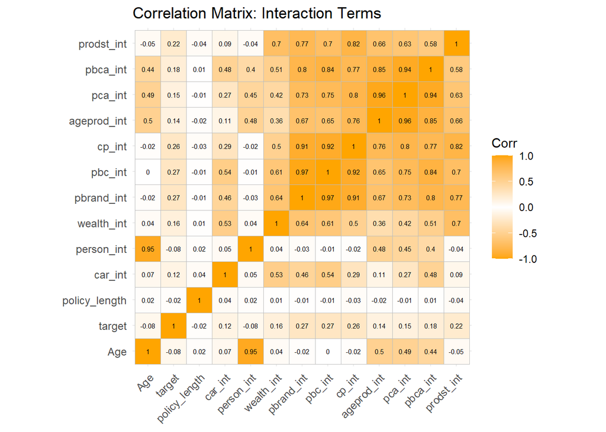

```r
sub_train %<>% mutate(car_int = carcat_tm * brand_tm,
                      person_int =  gender_tm * Age,
                      wealth_int = luxury_tm * state_tm,
                      pbrand_int = product_tm * brand_tm,
                      pbc_int = product_tm * brand_tm * carcat_tm,
                      cp_int = carcat_tm * product_tm,
                      ageprod_int = product_tm * Age,
                      pca_int = product_tm * carcat_tm * Age,
                      pbca_int = product_tm * brand_tm * carcat_tm * Age,
                      prodst_int = product_tm * state_tm)
sub_test %<>% mutate(car_int = carcat_tm * brand_tm,
                     person_int = gender_tm * Age,
                     wealth_int = luxury_tm * state_tm,
                     pbrand_int = product_tm * brand_tm,
                     pbc_int = product_tm * brand_tm * carcat_tm,
                     cp_int = carcat_tm * product_tm,
                     ageprod_int = product_tm * Age,
                     pca_int = product_tm * carcat_tm * Age,
                     pbca_int = product_tm * brand_tm * carcat_tm * Age,
                     prodst_int = product_tm * state_tm)

cor_int <- cor(sub_train[,c(1:3,12:21)])

ggcorrplot::ggcorrplot(cor_int, colors = c("orange","white","orange"), lab = TRUE,
                       lab_size = 2, tl.cex = 9,
                       title = "Correlation Matrix: Interaction Terms")
```

Because some interaction terms include the same predictor variables, it makes sense that they would have strong correlations with each other. For example, the `Age` and `person_int` have a correlation of 0.95 because `person_int` is `Age * Gender`.

Unlike the target mean encoded terms, where `product_tm` had the strongest correlation with the target variable (0.24), there are a few more interaction terms that have slightly better correlations with the target variable: `pbrand_int` (0.27), `pbc_int` (0.27), and `cp_int` (0.26). However, this is not surprising, given each of these interaction terms includes `product_tm`. In fact, the majority of interactions terms include product_tm, which explains the cluster of highly correlated values in the upper right corner of the correlation plot.

## 3.7 Summary

Through feature engineering, we have created several different variables for use in machine learning. These variables were created to identify possible trends between a certain predictor and the target variable, or between combinations of predictor variables and the target variable. While it will be unlikely that we will end up using all of the engineered variables in the model, we have several combinatorial options to choose from.

# 4 Machine Learning

When testing out various machine learning models in practice, the two metrics of highest importance are accuracy and speed. Building and training a neural network might create the most accurate model, but it takes an incredible amount of computer processing power. On the other hand, algorithms like decision trees, KNN (k-nearest neighbors) or Naive Bayes are fairly straightforward and thus computationally quick. In the middle are improvements on the more straightforward algorithms: random forests, adaptive boosting, and gradient boosting are all ways to improve on the rudimentary classifications by decision trees.

Our current task is binary classification with a relatively small dataset (the test set only has ~1200 rows), so we can afford to use some more computationally intensive methods. I will start by building a model using the k-nearest neighbor algorithm. This will allow us to quickly determine a baseline accuracy for the model. That way, as we add or drop new variables, we can run the new set of predictors through the algorithm again and compare it to the baseline model.

## 4.1 Pre-Processing

Before building the data through any sort of model, we should divide `sub_train` into a training and validation set. By creating a validation set, we can see what our model predicts for the target variable and evaluate its performance. If we simply trained our model on `sub_train` (the data frame we ended up with at the end of the Feature Engineering section), we would be blindly predicting the target variable for the test set, with no way to evaluate if our model did a good job or not. A good rule of thumb is that 75% of the training set is split into the new “training” set, and 25% goes into the validation dataset. I’ll call them `a` and `b`, respectively.

```r
set.seed(2041)
ndx <- sample(nrow(sub_train), .75*nrow(sub_train))
a <- sub_train[ndx,]
b <- sub_train[-ndx,]
```

Let’s make sure the proportion of the target variable is similar between the training and test sets.

```r
prop.table(table(a$target))
```

```
##
##         0         1
## 0.8811127 0.1188873
```

```r
prop.table(table(b$target))
```

```
##
##         0         1
## 0.8748344 0.1251656
```

Looks good!

Because we are classifying the target variable into either a 0 or 1, we should convert it to a factor.

```r
a$target <- as.factor(a$target)
b$target <- as.factor(b$target)
```

One way to improve the performance of a machine learning model out of the gate is to implement **cross-validation**. The `caret` package allows us to implement this seamlessly into the model with its `trainControl()` function.

```r
ctrl <- caret::trainControl(method = "cv", number = 10)
```

In a similar way to how we split the data into training data into training and validation sets, cross-validation takes our new set of training data and runs the model on a randomly selected subset of it. This process is repeated the number of times specified in the `number` argument.

## 4.2 Baseline KNN Model

Great! We are ready to train the model.

```r
set.seed(2041)
KNNmodel <- train(target ~ ., data = a, method = "knn",
                  trControl = ctrl, metric = "Kappa")
KNNmodel
```

```
## k-Nearest Neighbors
##
## 9059 samples
##   20 predictor
##    2 classes: '0', '1'
##
## No pre-processing
## Resampling: Cross-Validated (10 fold)
## Summary of sample sizes: 8153, 8154, 8153, 8153, 8153, 8152, ...
## Resampling results across tuning parameters:
##
##   k  Accuracy   Kappa
##   5  0.8658803  0.1425704
##   7  0.8701868  0.1146719
##   9  0.8741603  0.1079409
##
## Kappa was used to select the optimal model using the largest value.
## The final value used for the model was k = 5.
```

You can see how cross-validation was incorporated in the model above: about 8153/9059 (~90%) samples of the data were used to actually train the model. In addition, the `caret` package automatically selects which parameters are best for the KNN model. If we wanted, we could specify specific parameters using the `expand.grid` function. Details on what parameters can be specified for each model can be found in [Max Kuhn’s package documentation](https://topepo.github.io/caret/train-models-by-tag.html).

Now we can see how the model performs when evaluated against the validation set.

```r
set.seed(2041)
KNNpred <- predict(KNNmodel, b)
postResample(pred = KNNpred, obs = b$target)
```

```
##  Accuracy     Kappa
## 0.8605960 0.1532537
```

```r
pROC::auc(pROC::roc(b$target, as.numeric(KNNpred)))
```

```
## Area under the curve: 0.5576
```

First, what do these metrics mean?

- Accuracy: measures how well the model classified the target variable (number of true positives + number of true negatives/ number of observations)
- Kappa: measures how well the model classified the target variable compared to if the results were guessed randomly. In this context, we would compare the predicted results to a 50/50 chance that the target variable was a 0 or a 1.
- Area under the curve: the “curve” is the ROC curve, which plots the true positive rate against the false positive rate. The AUC (area under the curve) measures the probability of the model ranking a random positive example higher than a random negative example against a logistic regression model. The more predictions a model gets correct, the higher its AUC value will be.

The validation set had a lower accuracy and higher Kappa value compared to the cross-validated model (Accuracy = 0.8658803, Kappa = 0.1425704). This could be because there were more data points using the entire training dataset instead of a cross-validated subset of it. As a result, the model was able to determine the results better than random chance.

## 4.3 Improving Model Performance

While an accuracy of 86% is pretty good, a low Kappa value of 0.1532 doesn’t make this model much more useful than randomly guessing the target variable. There are a number of ways we can go about improving the performance of this model:

- Use different algorithms to build the model
- Oversample the minority class of the target variable (i.e. improve the dataset by sampling more customers that had filed a claim than there actually are)
- Evaluate the model using other performance metrics than Kappa (ROC, Accuracy)
- Try different combinations of predictor variables

**Note**: At this stage, the model building process becomes very iterative. Much trial and error is involved determining which methods work to improve the overall model, which work best with certain algorithms, and which weaken the model performance. To reduce the amount of code and knitting time needed for this document, several different models were tested outside of this document. The model outlined below is the best working one, according to the score it received when submitted to the competition website.

## 4.4 Best Working Model

Ultimately, I did not end up using many of the variables that were included as part of `sub_train` or `sub_test`. There is are only two interaction term: `person_int`, which is between gender and age, and `car_int`, which is between car category and car brand. Additionally, I converted all of the categorical variables to numeric using target mean encoding.

```r
library(caret)
library(ROSE)
library(pROC)
train <- read.csv("trainwave6.csv")
test <- read.csv("testwave6.csv")
glimpse(train)
```

```
## Rows: 12,079
## Columns: 11
## $ Age        <int> 30, 79, 43, -1, 20, 37, 40, 43, 71, 58, 43, 45, 51, -1, 38,~
## $ No_Pol     <int> 1, 1, 1, 1, 3, 2, 3, 1, 2, 1, 1, 1, 1, 2, 1, 1, 1, 1, 1, 1,~
## $ state_tm   <dbl> 0.07799014, 0.07799014, 0.07799014, 0.07799014, 0.16744314,~
## $ person_int <dbl> 3.5525798, 8.5007514, 5.0920310, -0.1184193, 3.4361233, 4.3~
## $ product_tm <dbl> 0.165612953, 0.165612953, 0.165612953, 0.003709592, 0.20164~
## $ brand_tm   <dbl> 0.16180905, 0.16180905, 0.16180905, 0.03836834, 0.03836834,~
## $ car_int    <dbl> 0.021942024, 0.021654480, 0.021942024, 0.003366724, 0.00336~
## $ luxury_tm  <dbl> 0.14399800, 0.14399800, 0.14399800, 0.03836834, 0.03836834,~
## $ lagosCC    <int> 0, 0, 0, 0, 0, 0, 0, 0, 0, 0, 0, 0, 0, 1, 1, 0, 0, 0, 0, 0,~
## $ missingCS  <int> 0, 0, 0, 1, 0, 0, 0, 1, 0, 0, 1, 0, 0, 0, 0, 0, 1, 0, 0, 0,~
## $ target     <int> 0, 1, 0, 0, 1, 0, 0, 0, 0, 0, 0, 0, 1, 0, 0, 0, 0, 0, 0, 0,~
```

```r
glimpse(test)
```

```
## Rows: 1,202
## Columns: 10
## $ Age        <int> 46, 32, 45, 58, -1, 64, -1, 35, 22, 38, 40, 39, 72, 36, -1,~
## $ No_Pol     <int> 1, 1, 2, 1, 1, 2, 1, 1, 1, 3, 2, 1, 1, 1, 1, 1, 1, 1, 1, 2,~
## $ state_tm   <dbl> 0.17404737, 0.17404737, 0.17404737, 0.07799014, 0.16744314,~
## $ person_int <dbl> 4.9498046, 3.7894184, 4.8422002, 6.2410580, -0.1718062, 7.5~
## $ lagosCC    <int> 0, 0, 0, 0, 1, 1, 1, 1, 1, 0, 0, 0, 0, 0, 0, 0, 0, 0, 0, 1,~
## $ missingCS  <int> 0, 0, 0, 1, 0, 0, 0, 0, 0, 0, 0, 1, 0, 0, 0, 0, 1, 0, 0, 0,~
## $ product_tm <dbl> 0.165612953, 0.165612953, 0.165612953, 0.003709592, 0.16561~
## $ brand_tm   <dbl> 0.12440725, 0.03836834, 0.10450623, 0.16180905, 0.12440725,~
## $ car_int    <dbl> 0.010916420, 0.003366724, 0.014171508, 0.021942024, 0.01687~
## $ luxury_tm  <dbl> 0.14399800, 0.03836834, 0.14399800, 0.14399800, 0.14399800,~
```

In the same way we did with the KNN model, we can split the training set into training and validation sets, `a` and `b`. We also can once again convert the target variables in each set into a factor.

```r
set.seed(2041)
ndx <- sample(nrow(train), .75*nrow(train))
a <- train[ndx,]
b <- train[-ndx,]

a$target <- as.factor(a$target)
b$target <- as.factor(b$target)
levels(a$target) <- c("X0","X1")
```

Something we did not explore in the baseline model was oversampling. If we look at the proportion of the target variable classes again, we can see there is a significantly smaller proportion of customers that did file a claim (the 1’s).

```r
#initial proportions
prop.table(table(a$target))
```

```
##
##        X0        X1
## 0.8811127 0.1188873
```

```r
#after oversampling
synth <- ovun.sample(target ~ ., data = a, method = "over", p = 0.24, seed = 2041)$data
prop.table(table(synth$target))
```

```
##
##        X0        X1
## 0.7565877 0.2434123
```

Once again, we’ll establish our hyperparameters with 10 folds for cross-validation. This time, we’ll also add the `twoClassSummary` function to compare performance metrics across the different folds.

```r
set.seed(2041)
ctrl <- trainControl(method = "cv", number = 10,summaryFunction = twoClassSummary, classProbs = TRUE)
ctrl$sampling <- "up"
```

Now we can train the model with our oversampled data. I found that a random forest classifier worked best with this data, although I also tried `xgboost` (extreme gradient boosting) and `adaboost` (adapative boosting).

```r
RFmodel <- train(target ~ ., data = synth, method = "rf", metric = "ROC",
                 trControl = ctrl)
```

The next step is to see how the model performed:

```r
RFpred <- predict(RFmodel, b)
levels(RFpred) <- c(0,1)
postResample(pred = RFpred, obs = b$target)
```

```
##  Accuracy     Kappa
## 0.7807947 0.2375762
```

```r
auc(roc(b$target, as.numeric(RFpred)))
```

```
## Area under the curve: 0.656
```

The baseline model had an accuracy of 0.8605, a Kappa value of .15325, and an AUC of 0.5576. While its accuracy is better than the random forest model, this is deceiving. As discussed before, accuracy is the measure of how well the model classified the target variable based on a positive/negative rate. When evaluating the model, there are only two categories. If those categories were equally represented in the data (i.e. 50/50 split), then the accuracy would be a more reliable metric. However, because the vast majority of customers did *not* file a claim, the model would follow suit and predict a similar proportion distribution.

Let’s say you were at a fair and there was a bowl of 20 vanilla cookies and 2 chocolate cookies The attendant asks you to make a prediction of which type of fruit you’re going to pull out. If you kept reaching in (with your eyes closed) and succesfully kept predicting that you would pull a vanilla cookies, you’d be pretty accurate. However, this doesn’t inherently mean you have some sort of magic ability to pick out the exact cookie you predicted. It just means the sample distribution is heavily tilted in your favor.

Instead, we can use the kappa value and AUC to better represent the model performance.

All that’s left is to use our model to predict the target variable for our test set:

```r
RFpred_real <- predict(RFmodel, test)
levels(RFpred_real) <- c(0,1)
prop.table(table(RFpred_real))
```

```
## RFpred_real
##         0         1
## 0.8269551 0.1730449
```

This proportion distribution is about mid-way between the distributions for our normal training set and our oversampled training set. Initially, I thought this would have a bearing on the outcome, but it turns out that was not the case.

## 4.5 Other Model Performance

I started keeping track of each model’s metrics and its corresponding score on the competition website. Here is a scatterplot of all the other models I tried, plotting their Kappa value vs. the competition score:

**Note**: the competition scores on the Zindi website have since been adjusted to now reflect how all the models performed on the hidden test set. While my best score initially was 0.25, it is now reflected on the website as 0.2857. In fact, my second best model actually got a final score of 0.3057 (an improvement from 0.2456), but unfortunately this wasn’t counted towards the final standings.

```r
library(ggplot2)
kappa <- c(0.234,0.237,0.1924273, 0.2028258,0.2534521,0.2272815,0.2498679,
           0.2301400,0.2121602,0.2456711,0.2375762,0.2425416,0.2525471,0.2374172,.2237177,0.2401427,
           0.2321995)
auc <- c(NA,0.658,0.594,0.6029,0.6899,0.6525,0.678,0.6309,0.6299,0.6539,0.656,0.6527,0.7156,
         0.6584,.6499,.662,0.6539)
acc <- c(0.737,0.778,0.8271523, 0.8228477,0.7549699,0.7728477,0.7658940,
         0.8082781,0.7887417,0.7930464,0.7807947,0.7910596,0.7205298,0.7771523,
         .7721854,0.754967,.7771523)
score <- c(0.212121,0.205479,0.141176,0.189473, 0.198830, 0.158273, 0.222222,
           0.146341,0.183908,0.177419,0.25,0.2,0.23176,.205128,.194444,.21126,.232876)
no <- c(19,21,23,24,25,26,27,30,31,32,33,34,35,36,40,41,45)
method <- c("ada","ada","rf","rf","ada","rf", "rf", "knn", "rf", "ada","rf","ada","rf","rf","catboost","catboost","rf")

df <- data.frame(kappa,auc,acc,score,no,method)
df %>% arrange(-score)
```

| kappa | auc | acc | score | no | method |
| --- | --- | --- | --- | --- | --- |
| 0.2375762 | 0.6560 | 0.7807947 | 0.250000 | 33 | rf |
| 0.2321995 | 0.6539 | 0.7771523 | 0.232876 | 45 | rf |
| 0.2525471 | 0.7156 | 0.7205298 | 0.231760 | 35 | rf |
| 0.2498679 | 0.6780 | 0.7658940 | 0.222222 | 27 | rf |
| 0.2340000 | NA | 0.7370000 | 0.212121 | 19 | ada |
| 0.2401427 | 0.6620 | 0.7549670 | 0.211260 | 41 | catboost |
| 0.2370000 | 0.6580 | 0.7780000 | 0.205479 | 21 | ada |
| 0.2374172 | 0.6584 | 0.7771523 | 0.205128 | 36 | rf |
| 0.2425416 | 0.6527 | 0.7910596 | 0.200000 | 34 | ada |
| 0.2534521 | 0.6899 | 0.7549699 | 0.198830 | 25 | ada |

[output cut: 7 more lines]

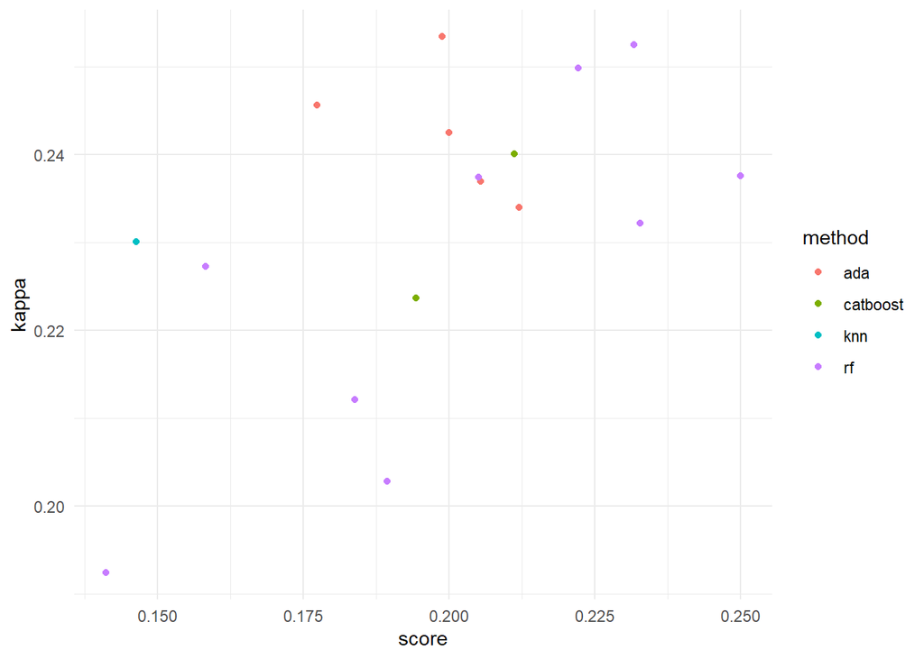

```r
ggplot(df, aes(score,kappa,color=method)) + geom_point() + theme_minimal()
```

There is a positive correlation between the kappa value and score, but it is not 1. This emphasizes the importance not relying on one metric to evaluate a model.

# 5 Conclusion

Thank you so much for making it to the end! I learned an incredible amount about the model-building process through this project. Above all else, I had a lot of fun. There was nothing like getting a dopamine hit each time I saw an improved score after submitting a new set of predictions. Moving forward, I hope to be able to build more models in tasks that require more pre-processing and feature engineering, like NLP or computer vision.

I know I have a lot to improve on, so if you have any feedback or questions, please feel free to reach me at eckollmer@gmail.com